# Proyecto Python: Análisis Exploratorio de Datos

## Evolución de la infraestructura en escuelas de Costa Rica entre los años 2014 y 2020

Nombre: Vladimir Sagot Muñoz

Curso: Lenguajes de Programación Orientados al Análisis de Datos

Profesor: Sergio Morales Esquivel

## Introducción

Para elaborar el proyecto de análisis exploratorio de datos (EDA) en Python del curso, se utilizará el dataset “Infraestructura en escuelas 2014-2020”. El cual se encuentra en el portal de datos abiertos del Ministerio de Educación Pública de Costa Rica en el siguiente enlace: https://www.mep.go.cr/indicadores_edu/autotabulaciones.html

Este conjunto de datos contiene información sobre el estado de la infraestructura en las escuelas de Costa Rica, desde el año 2014 hasta el 2020. Por lo que presenta un valioso potencial para estudiar **la evolución de la infraestructura educativa en el país, en específico en las escuelas públicas.**

Para este trabajo de EDA, se profundizará en el área de la **evolución de la infraestructura educativa (específicamente en las aulas construidas) y la infraestructura tecnológica (acceso a internet adquisión de dispositivos tecnológicos).**

El dataset cuenta con un total de 28.251 vistas y 77 atributos. Entre los cuales no se incluyen atributos de tipo geográfico (aunque sí atributos de tipo categórico sobre ubicaciones) y temporales (año del curso lectivo registrado por centro educativo, de 2014 a 2020).

### Nomenclatura

El dataset seleccionado incluye indicadores de nomenclatura para algunos de sus atributos. Los cuales se describen a continuación:

| VARIABLE | DESCRIPCIÓN | TIPO |
| --- | --- | --- |
| CÓDIGO | Código Presupuestario | Alfabético |
| CIRES | Circuito escolar | Alfabético |
| PR | Número de Provincia | Alfabético |
| CAN | Número de Cantón | Alfabético |
| DIS | Número de Distrito | Alfabético |
| SECTOR | Sector: 1 = Público, 2 = Privado, 3 = Subvencionado | Alfabético |
| ZONA | Zona: 1 = Rural, 2 = Urbana | Numérico |

El Código Presupuestario es un valor de carácter único por centro educativo público en el país. Por lo que será el principal identificador para diferenciar las escuelas públicas en el estudio de datos.

## Objetivos

### Objetivo general

Conocer la evolución de la infraestructura educativa de las escuelas públicas en Costa Rica entre los años 2014 y 2020 a través del análisis exploratorio de datos (EDA).

### Objetivos específicos

- Describir la evolución entre 2014 y 2020 de la infraestructura de aulas en las escuelas públicas de Costa Rica.
- Describir el aumento en la adquisición de recursos tecnológicos en las escuelas públicas de Costa Rica entre el 2014 y el 2020.
- Explorar la evolución regional en la infraestructura de aulas y de tecnología en las escuelas públicas de Costa Rica entre 2014 y 2020.

## Ingestión de datos

La primera parte del proyecto consiste en la etapa de ingestión de datos. Previamente se transformó el archivo de datos original del dataset seleccionado de un XLSX a uno tipo CSV. Además, se limpiaron "dobles espacios" en los nombres de algunos atributos, para evitar problemas durante el procesamiento de la información.

```python
import pandas as pd
df = pd.read_csv("dataset-escuelas.csv", encoding = 'utf8')
df.head()
```

|  | CURSO LECTIVO | CODIGO | NOMBRE | DIRECCION REGIONAL | CIRES | PR | CAN | DIS | PROVINCIA | CANTON | ... | Computadoras portátil sin internet, para usos Pedogógicos y Administrativos | Computadoras portátil con internet, para usos administrativos | Computadoras portátil sin internet, para usos administrativos | Agua | Sanitario | Luz | Servicio Biblioteca | Planes de gestión de riesgo | Servicio de Internet | Página web |
| --- | --- | --- | --- | --- | --- | --- | --- | --- | --- | --- | --- | --- | --- | --- | --- | --- | --- | --- | --- | --- | --- |
| 0 | 2014 | 2256.0 | EL PORVENIR | LIBERIA | 1 | 5 | 10 | 3 | GUANACASTE | LA CRUZ | ... | 0 | 0 | 0 | Acueducto Rural o Comunal (ASADAS o CAAR). | Tanque Séptico | ICE o CNFL | No | No | Sí | No disponible |
| 1 | 2014 | NaN | DÚRIKA | GRANDE DE TERRABA | 1 | 6 | 3 | 1 | PUNTARENAS | BUENOS AIRES | ... | 1 | 0 | 0 | Empresa o Cooperativa | Tanque Séptico | Otra fuente | No | Sí | Sí | No disponible |
| 2 | 2014 | NaN | VIRGEN MARIA DEL MILAGRO | DESAMPARADOS | 1 | 1 | 3 | 1 | SAN JOSE | DESAMPARADOS | ... | 0 | 2 | 0 | Acueducto A y A | Alcantarillado Sanitario | ICE o CNFL | No | Sí | Sí | No disponible |
| 3 | 2014 | 547.0 | REPUBLICA FEDERAL DE ALEMANIA | DESAMPARADOS | 1 | 1 | 3 | 7 | SAN JOSE | DESAMPARADOS | ... | 0 | 0 | 0 | Acueducto Rural o Comunal (ASADAS o CAAR). | Tanque Séptico | ICE o CNFL | No | No | Sí | No disponible |
| 4 | 2014 | 457.0 | CIPRESES | SAN JOSE CENTRAL | 4 | 1 | 18 | 1 | SAN JOSE | CURRIDABAT | ... | 0 | 0 | 0 | Acueducto A y A | Tanque Séptico | ICE o CNFL | No | No | Sí | No disponible |

5 rows × 77 columns

### Exploración de características del dataset

A través del comando *info* y la especificación *memory_usage='deep'* se obtiene un resumen de todos los atributos cargados, así como los distintos tipos de datos y una aproximación de la memoria que utilizará el dataset.

Una ventaja en el *dataset* seleccionado, es que las etiquetas que describen cada columna, tienen nombres descriptivos que ayudan a entender la dimensión semántica de cada columna de información.

```python
df.info(memory_usage='deep')
```

```
<class 'pandas.core.frame.DataFrame'>
RangeIndex: 28251 entries, 0 to 28250
Data columns (total 77 columns):
 #   Column                                                                         Non-Null Count  Dtype
---  ------                                                                         --------------  -----
 0   CURSO LECTIVO                                                                  28251 non-null  int64
 1   CODIGO                                                                         26133 non-null  float64
 2   NOMBRE                                                                         28251 non-null  object
 3   DIRECCION REGIONAL                                                             28251 non-null  object
 4   CIRES                                                                          28251 non-null  int64
 5   PR                                                                             28251 non-null  int64
 6   CAN                                                                            28251 non-null  int64
 7   DIS                                                                            28251 non-null  int64
 8   PROVINCIA                                                                      28251 non-null  object
 9   CANTON                                                                         28251 non-null  object
```

[output cut: 69 more lines]

## Limpieza de datos y optimización del uso de memoria del dataset

El dataset utilizado en este proyecto puede ser cargado por Pandas sin problema y, dado su tamaño regular, la optimización de su espacio en memoria no sería necesario. Sin embargo, por fines didácticos se aplicarán optimizaciones al mismo.

### Remover datos de tipo float

Conociendo los atributos del dataset, llama la atención la existencia de datos de tipo *float*. Dado que dentro del mismo solo se utilizan valores que son de forma lógica solamente de tipo *int*, por su semántica perteneciente a los números naturales.

Por lo que se realiza una exploración de los mismos, para verificar cómo se muestra a continuación, que todos los datos de tipo *float* pueden ser transformados a tipo *int*. La existencia de valores vacíos hace que de forma automática se indexen los valores como de punto flotante.

```python
df.select_dtypes(include=['float64'])
```

|  | CODIGO | Aulas Preescolar total | Aulas Preescolar buenas | Aula Integrada total | Aula Integrada buenas | Programa Aula Edad total | Programa Aula Edad buenas | Aulas no utilizadas total | Aulas no utilizadas buenas | Otros Laboratorios total | Otros Laboratorios buenos | Sala de Robótica total | Sala de Robótica buenas | Cubículos total | Cubículos buenos | Sodas total | Sodas buenas | Pupitres total | Pupitres buenos |
| --- | --- | --- | --- | --- | --- | --- | --- | --- | --- | --- | --- | --- | --- | --- | --- | --- | --- | --- | --- |
| 0 | 2256.0 | 1.0 | 1.0 | 0.0 | 0.0 | 0.0 | 0.0 | 0.0 | 0.0 | NaN | NaN | NaN | NaN | NaN | NaN | NaN | NaN | NaN | NaN |
| 1 | NaN | 0.0 | 0.0 | 0.0 | 0.0 | 0.0 | 0.0 | 1.0 | 1.0 | NaN | NaN | NaN | NaN | NaN | NaN | NaN | NaN | NaN | NaN |
| 2 | NaN | 3.0 | 3.0 | 0.0 | 0.0 | 0.0 | 0.0 | 0.0 | 0.0 | NaN | NaN | NaN | NaN | NaN | NaN | NaN | NaN | NaN | NaN |
| 3 | 547.0 | 2.0 | 1.0 | 0.0 | 0.0 | 0.0 | 0.0 | 0.0 | 0.0 | NaN | NaN | NaN | NaN | NaN | NaN | NaN | NaN | NaN | NaN |
| 4 | 457.0 | 1.0 | 0.0 | 0.0 | 0.0 | 0.0 | 0.0 | 1.0 | 0.0 | NaN | NaN | NaN | NaN | NaN | NaN | NaN | NaN | NaN | NaN |
| ... | ... | ... | ... | ... | ... | ... | ... | ... | ... | ... | ... | ... | ... | ... | ... | ... | ... | ... | ... |
| 28246 | 5887.0 | 1.0 | 1.0 | 0.0 | 0.0 | 0.0 | 0.0 | 1.0 | 1.0 | NaN | NaN | 0.0 | 0.0 | 0.0 | 0.0 | 0.0 | 0.0 | 27.0 | 20.0 |
| 28247 | 824.0 | 0.0 | 0.0 | 0.0 | 0.0 | 0.0 | 0.0 | 1.0 | 1.0 | NaN | NaN | 0.0 | 0.0 | 0.0 | 0.0 | 0.0 | 0.0 | 23.0 | 23.0 |
| 28248 | 2903.0 | 0.0 | 0.0 | 0.0 | 0.0 | 0.0 | 0.0 | 0.0 | 0.0 | NaN | NaN | 0.0 | 0.0 | 0.0 | 0.0 | 0.0 | 0.0 | 9.0 | 5.0 |
| 28249 | 2026.0 | 0.0 | 0.0 | 0.0 | 0.0 | 0.0 | 0.0 | 0.0 | 0.0 | NaN | NaN | 0.0 | 0.0 | 0.0 | 0.0 | 0.0 | 0.0 | 20.0 | 20.0 |
| 28250 | 5877.0 | 1.0 | 1.0 | 0.0 | 0.0 | 0.0 | 0.0 | 0.0 | 0.0 | NaN | NaN | 0.0 | 0.0 | 0.0 | 0.0 | 0.0 | 0.0 | 28.0 | 28.0 |

28251 rows × 19 columns

Con el conocimiento previo, se procede a modificar los tipos de las filas *float* a tipo *int*, indicando que en caso de no existir un valor, este tome el valor "-1". Una vez finalizado el proceso, se comprueba que no quedan tipos *float* en el dataframe.

<sub><sub>*Referencia: https://stackoverflow.com/questions/21291259/convert-floats-to-ints-in-pandas*</sub></sub>

```python
for dtypes in df.select_dtypes(include=['float64']):
    df[dtypes] = df[dtypes].fillna(-1).astype('int64')
df.select_dtypes(include=['float64'])
```

| 0 |
| --- |
| 1 |
| 2 |
| 3 |
| 4 |
| ... |
| 28246 |
| 28247 |
| 28248 |
| 28249 |
| 28250 |

28251 rows × 0 columns

Solo con este pequeño cambio se reduce en poco menos de 1 MB el tamaño del dataframe, y aparecen más datos de tipo *int64* (62 en total).

```python
df.info(memory_usage='deep')
```

```
<class 'pandas.core.frame.DataFrame'>
RangeIndex: 28251 entries, 0 to 28250
Data columns (total 77 columns):
 #   Column                                                                         Non-Null Count  Dtype
---  ------                                                                         --------------  -----
 0   CURSO LECTIVO                                                                  28251 non-null  int64
 1   CODIGO                                                                         28251 non-null  int64
 2   NOMBRE                                                                         28251 non-null  object
 3   DIRECCION REGIONAL                                                             28251 non-null  object
 4   CIRES                                                                          28251 non-null  int64
 5   PR                                                                             28251 non-null  int64
 6   CAN                                                                            28251 non-null  int64
 7   DIS                                                                            28251 non-null  int64
 8   PROVINCIA                                                                      28251 non-null  object
 9   CANTON                                                                         28251 non-null  object
```

[output cut: 69 more lines]

### Analizar el tipo de información que almacenan los distintos datos *int*

Dado los distintos subtipos de *int* que Pandas ofrece para almacenar datos, es importante analizar los rangos numéricos de cada atributo para ajustarlo acorde a su realidad y la optimización en el uso de espacio.

<sub><sub>*Referencia: https://www.dataquest.io/blog/pandas-big-data/*</sub></sub>

```python
import numpy as np
int_types = ["int8", "int16", "int32", "int64"]
for it in int_types:
    print(np.iinfo(it))
```

```
Machine parameters for int8
---------------------------------------------------------------
min = -128
max = 127
---------------------------------------------------------------

Machine parameters for int16
---------------------------------------------------------------
min = -32768
max = 32767
---------------------------------------------------------------

Machine parameters for int32
---------------------------------------------------------------
min = -2147483648
max = 2147483647
---------------------------------------------------------------

Machine parameters for int64
---------------------------------------------------------------
min = -9223372036854775808
max = 9223372036854775807
---------------------------------------------------------------
```

Como se muestra en los rangos de tipo *int* anteriores, y conociendo el dataset que se estudia, los valores mínimos y máximos en todo el dataset se encuentran entre los valores **[-1, 6878]**, eso quiere decir que todos los valores utilizados podrían ser transformados a *int16* sin ningún problema.

<sub><sub>*Referencia: https://stackoverflow.com/questions/12169170/find-the-max-of-two-or-more-columns-with-pandas*</sub></sub>

```python
print("Min number in all data frame: " + str(df.select_dtypes(include=['int64']).min(axis=1).min()))
print("Max number in all data frame: " + str(df.select_dtypes(include=['int64']).max(axis=1).max()))
```

```
Min number in all data frame: -1
Max number in all data frame: 6878
```

Se proceden a transformar todos los valores numéricos en *int16*.

```python
for dtypes in df.select_dtypes(include=['int64']):
    df[dtypes] = df[dtypes].fillna(-1).astype('int16')

df.info(memory_usage='deep')
```

```
<class 'pandas.core.frame.DataFrame'>
RangeIndex: 28251 entries, 0 to 28250
Data columns (total 77 columns):
 #   Column                                                                         Non-Null Count  Dtype
---  ------                                                                         --------------  -----
 0   CURSO LECTIVO                                                                  28251 non-null  int16
 1   CODIGO                                                                         28251 non-null  int16
 2   NOMBRE                                                                         28251 non-null  object
 3   DIRECCION REGIONAL                                                             28251 non-null  object
 4   CIRES                                                                          28251 non-null  int16
 5   PR                                                                             28251 non-null  int16
 6   CAN                                                                            28251 non-null  int16
 7   DIS                                                                            28251 non-null  int16
 8   PROVINCIA                                                                      28251 non-null  object
 9   CANTON                                                                         28251 non-null  object
```

[output cut: 69 more lines]

Solo con esta transformación de tipos, de *int64* a *int16*, el espacio en memoria del dataset **se redujo en unos 10 MB**.

### Analizar la información de tipo *object* para realizar transformaciones de tipo categórica

Se analiza la información contenida en el dataset de tipo *object*, para verificar cuál podría ser transformada a tipo *categorical*.

```python
df.select_dtypes(include=['object']).describe()
```

|  | NOMBRE | DIRECCION REGIONAL | PROVINCIA | CANTON | DISTRITO | POBLADO | Aulas: I y II Ciclos (incluye Asignaturas Especiales) total | Aulas: I y II Ciclos (incluye Asignaturas Especiales) buenas | Agua | Sanitario | Luz | Servicio Biblioteca | Planes de gestión de riesgo | Servicio de Internet | Página web |
| --- | --- | --- | --- | --- | --- | --- | --- | --- | --- | --- | --- | --- | --- | --- | --- |
| count | 28251 | 28251 | 28251 | 28251 | 28251 | 28251 | 28226 | 28226 | 28251 | 28251 | 28251 | 28251 | 28251 | 28251 | 28251 |
| unique | 3405 | 27 | 7 | 84 | 412 | 2595 | 95 | 91 | 18 | 10 | 7 | 6 | 6 | 6 | 7 |
| top | SAN RAFAEL | SAN CARLOS | PUNTARENAS | SAN CARLOS | SAN RAFAEL | SAN RAFAEL | 1 | 1 | Acueducto Rural o Comunal (ASADAS o CAAR). | Tanque Séptico | ICE o CNFL | No | Sí | Sí | No disponible |
| freq | 217 | 2153 | 5912 | 1626 | 592 | 389 | 4921 | 4910 | 12039 | 24239 | 20626 | 13529 | 17857 | 17767 | 16153 |

Antes de continuar con las transformaciones de tipo *categorical*, se detecta que Pandas clasificó dos atributos como *object* que deben ser clasificados como de tipo *int*. **Esto debido a que en estos atributos se contiene el valor "N.R.", para centros educativos que no dieron respuesta a ese valor.** Se procede a realizar esta transformación para los siguientes atributos:

- Aulas: I y II Ciclos (incluye Asignaturas Especiales) total
- Aulas: I y II Ciclos (incluye Asignaturas Especiales) buenas

```python
atributos = ["Aulas: I y II Ciclos (incluye Asignaturas Especiales) total", "Aulas: I y II Ciclos (incluye Asignaturas Especiales) buenas"]

# Con el método "replace" se sustituyen todos los valores "N.R." por un "-1", así se facilita la transformación de la columna a int.
for atributo in atributos:
    df[atributo].replace({"N.R.": "-1"}, inplace=True)

for atributo in atributos:
    df[atributo] = df[atributo].fillna(-1).astype('int16')

df.info(memory_usage='deep')
```

```
<class 'pandas.core.frame.DataFrame'>
RangeIndex: 28251 entries, 0 to 28250
Data columns (total 77 columns):
 #   Column                                                                         Non-Null Count  Dtype
---  ------                                                                         --------------  -----
 0   CURSO LECTIVO                                                                  28251 non-null  int16
 1   CODIGO                                                                         28251 non-null  int16
 2   NOMBRE                                                                         28251 non-null  object
 3   DIRECCION REGIONAL                                                             28251 non-null  object
 4   CIRES                                                                          28251 non-null  int16
 5   PR                                                                             28251 non-null  int16
 6   CAN                                                                            28251 non-null  int16
 7   DIS                                                                            28251 non-null  int16
 8   PROVINCIA                                                                      28251 non-null  object
 9   CANTON                                                                         28251 non-null  object
```

[output cut: 69 more lines]

Se verifica que ahora los atributos *object* presentes son efectivamente de ese tipo (según la lógica del dataset) y se procede a iniciar su optimización.

Como se visualiza en la descripción de los datos, todos representan una pequeña tasa de valores únicos frente a su valor total. Por lo que transformar todos estos atributos a tipo *categorical* es óptimo.

**Es importante destacar que el tipo de atributo "NOMBRE" no es único de un centro educativo, ya que varios pueden tener el mismo nombre en diferentes circuitos escolares.**

```python
df.select_dtypes(include=['object']).describe()
```

|  | NOMBRE | DIRECCION REGIONAL | PROVINCIA | CANTON | DISTRITO | POBLADO | Agua | Sanitario | Luz | Servicio Biblioteca | Planes de gestión de riesgo | Servicio de Internet | Página web |
| --- | --- | --- | --- | --- | --- | --- | --- | --- | --- | --- | --- | --- | --- |
| count | 28251 | 28251 | 28251 | 28251 | 28251 | 28251 | 28251 | 28251 | 28251 | 28251 | 28251 | 28251 | 28251 |
| unique | 3405 | 27 | 7 | 84 | 412 | 2595 | 18 | 10 | 7 | 6 | 6 | 6 | 7 |
| top | SAN RAFAEL | SAN CARLOS | PUNTARENAS | SAN CARLOS | SAN RAFAEL | SAN RAFAEL | Acueducto Rural o Comunal (ASADAS o CAAR). | Tanque Séptico | ICE o CNFL | No | Sí | Sí | No disponible |
| freq | 217 | 2153 | 5912 | 1626 | 592 | 389 | 12039 | 24239 | 20626 | 13529 | 17857 | 17767 | 16153 |

Se procede a realizar la transformación de todos los datos tipo *object*.

```python
for dtypes in df.select_dtypes(include=['object']):
    df[dtypes] = df[dtypes].astype('category')

df.info(memory_usage='deep')
```

```
<class 'pandas.core.frame.DataFrame'>
RangeIndex: 28251 entries, 0 to 28250
Data columns (total 77 columns):
 #   Column                                                                         Non-Null Count  Dtype
---  ------                                                                         --------------  -----
 0   CURSO LECTIVO                                                                  28251 non-null  int16
 1   CODIGO                                                                         28251 non-null  int16
 2   NOMBRE                                                                         28251 non-null  category
 3   DIRECCION REGIONAL                                                             28251 non-null  category
 4   CIRES                                                                          28251 non-null  int16
 5   PR                                                                             28251 non-null  int16
 6   CAN                                                                            28251 non-null  int16
 7   DIS                                                                            28251 non-null  int16
 8   PROVINCIA                                                                      28251 non-null  category
 9   CANTON                                                                         28251 non-null  category
```

[output cut: 69 more lines]

Como se demuestra en el resultado final, **el uso de memoria del dataset pasa de 40.8 MB a 4.6 MB**. Casi una décima parte de su tamaño original, gracias a las optimizaciones realizadas.

### Ajustes para mejorar la interpretación de datos

Después de realizados distintos pasos de optimización y limpieza de datos, se detectó que las columnas "SECTOR" y "ZONA" se almacenan como tipo *int* y, que según la nomenclatura del dataset, estos responden a categorías. Por lo que se procederá a ajustarlos para que más adelante su interpretación sea de un más fácil manejo.

```python
df["SECTOR"] = df["SECTOR"].astype('category')
df["SECTOR"] = pd.Categorical(df["SECTOR"]).rename_categories({1: 'Público', 2: 'Privado', 3: 'Subvencionado'})
df["SECTOR"].head()
```

```
0    Público
1    Privado
2    Privado
3    Público
4    Público
Name: SECTOR, dtype: category
Categories (3, object): ['Público', 'Privado', 'Subvencionado']
```

```python
df["ZONA"] = df["ZONA"].astype('category')
df["ZONA"] = pd.Categorical(df["ZONA"]).rename_categories({1: 'Rural', 2: 'Urbana'})
df["ZONA"].head()
```

```
0    Urbana
1     Rural
2     Rural
3     Rural
4     Rural
Name: ZONA, dtype: category
Categories (2, object): ['Rural', 'Urbana']
```

<sub><sub>*Referencia: https://pandas.pydata.org/pandas-docs/stable/reference/api/pandas.Series.cat.rename_categories.html*</sub></sub>

También se detectó que la columna "Servicio de Internet", importante para utilizar en los análisis siguientes, contiene información categórica de tres tipos, sin embargo por diferencias de forma Pandas la clasifica como más de tres categorías. Como se muestra a continuación.

```python
df["Servicio de Internet"].value_counts()
```

```
Sí             17767
No              3594
SI              3474
No responde     2297
NO              1022
NR                97
Name: Servicio de Internet, dtype: int64
```

Por lo que se procede a homogeneizar los valores según su significado semántico.

```python
df["Servicio de Internet"].replace("SI", "Sí", inplace=True)

df["Servicio de Internet"].replace("NO", "No", inplace=True)

df["Servicio de Internet"].replace("NR", "No responde", inplace=True)
```

Como se muestra, el valor semántico de las tres categorías fue homogenizado en su forma de escritura.

```python
df["Servicio de Internet"].value_counts()
```

```
Sí             21241
No              4616
No responde     2394
Name: Servicio de Internet, dtype: int64
```

### Manejo de valores nulos o sin información

Por las características del dataset seleccionado, se consignan los espacios sin información de tipo numérica con un "-1". Dado que el dataset trabaja con números naturales en todas sus columnas.

El proceso de colocación de "-1" en las vistas en donde falta información numérica se realizó a través de los distintos subprocesos descritos anteriormente.

### Corrección de faltas ortográficas en los nombres de las columnas

El dataset seleccionado contiene algunos errores ortográficos o de formato en algunos de los nombres de sus columnas, por lo que se proceden a corregir para mejorar el análisis de información.

```python
df.rename(columns={"CODIGO": "CÓDIGO", "Laboratorio Informática Total": "Laboratorio Informática total", "Computadoras escritorio con internet, para usos Pedogógicos": "Computadoras escritorio con internet, para usos Pedagógicos", "Computadoras escritorio sin internet, para usos Pedogógico": "Computadoras escritorio sin internet, para usos Pedagógicos", "Computadoras escritorio con internet, para usos Pedogógicos y Administrativos": "Computadoras escritorio con internet, para usos Pedagógicos y Administrativos", "Computadoras escritorio sin internet, para usos Pedogógicos y Administrativos": "Computadoras escritorio sin internet, para usos Pedagógicos y Administrativos", "Computadoras portátil con internet, para usos Pedogógicos": "Computadoras portátil con internet, para usos Pedagógicos", "Computadoras portátil sin internet, para usos Pedogógicos": "Computadoras portátil sin internet, para usos Pedagógicos", "Computadoras portátil con internet, para usos Pedogógicos y Admnistrativos": "Computadoras portátil con internet, para usos Pedagógicos y Administrativos", "Computadoras portátil sin internet, para usos Pedogógicos y Administrativos": "Computadoras portátil sin internet, para usos Pedagógicos y Administrativos "}, errors="raise", inplace=True)

df.info(memory_usage='deep')
```

```
<class 'pandas.core.frame.DataFrame'>
RangeIndex: 28251 entries, 0 to 28250
Data columns (total 77 columns):
 #   Column                                                                         Non-Null Count  Dtype
---  ------                                                                         --------------  -----
 0   CURSO LECTIVO                                                                  28251 non-null  int16
 1   CÓDIGO                                                                         28251 non-null  int16
 2   NOMBRE                                                                         28251 non-null  category
 3   DIRECCION REGIONAL                                                             28251 non-null  category
 4   CIRES                                                                          28251 non-null  int16
 5   PR                                                                             28251 non-null  int16
 6   CAN                                                                            28251 non-null  int16
 7   DIS                                                                            28251 non-null  int16
 8   PROVINCIA                                                                      28251 non-null  category
 9   CANTON                                                                         28251 non-null  category
```

[output cut: 69 more lines]

### Guardar el dataframe optimizado para su futuro uso

Para no repetir el proceso de optimización cada vez que se desee utilizar el dataset, se procederá a almacenar en el disco duro como un objeto Dataframe serializado, esto con las facilidades que ofrece Python.

<sub><sub>*Referencia: https://pandas.pydata.org/pandas-docs/stable/reference/api/pandas.DataFrame.to_pickle.html*</sub></sub>

```python
# Se guarda el dataframe como un objeto, no es un formato accesible para la lectura común.
df.to_pickle("./dataset-escuelas-optimizado.pkl")
```

**Con el siguiente código es que se cargará el Dataframe optimizado, para el análisis de datos que vendrá más adelante.**

```python
%matplotlib inline

import pandas as pd
import matplotlib.pyplot as plt

df = pd.read_pickle("./dataset-escuelas-optimizado.pkl")
# df.head()
# df.info(memory_usage='deep')

mask_code = df["CÓDIGO"] != -1
mask_zone = df["SECTOR"] == "Público"

df_public_schools = df[mask_code & mask_zone]
```

### Verificación de Códigos Presupuestarios en las escuelas públicas

Como se muestra a continuación, no existe una escuela pública sin código presupuestario. Esto facilitará el análisis de las mismas a través de este identificador único.

```python
mask_code = df["CÓDIGO"] == -1
mask_zone = df["SECTOR"] == "Público"

df[mask_code & mask_zone]
```

|  | CURSO LECTIVO | CÓDIGO | NOMBRE | DIRECCION REGIONAL | CIRES | PR | CAN | DIS | PROVINCIA | CANTON | ... | Computadoras portátil sin internet, para usos Pedagógicos y Administrativos | Computadoras portátil con internet, para usos administrativos | Computadoras portátil sin internet, para usos administrativos | Agua | Sanitario | Luz | Servicio Biblioteca | Planes de gestión de riesgo | Servicio de Internet | Página web |
| --- | --- | --- | --- | --- | --- | --- | --- | --- | --- | --- | --- | --- | --- | --- | --- | --- | --- | --- | --- | --- | --- |

0 rows × 77 columns

Además, solo en tres ocasiones un código presupuestario se repite dentro de un mismo año. Esto puede deberse a situaciones particulares dentro de la Administración Pública. Ya que los códigos que se repiten pertenecen a escuelas que están dentro de una misma región.

```python
df_public_schools_count_code = df_public_schools.groupby(["CURSO LECTIVO", "CÓDIGO"])["CÓDIGO"].count()

df_public_schools_count_code[df_public_schools_count_code > 1]
```

```
CURSO LECTIVO  CÓDIGO
2014           2377      2
               3501      2
2015           3501      2
Name: CÓDIGO, dtype: int64
```

```python
df_public_schools[df_public_schools["CÓDIGO"] == 2377]
```

|  | CURSO LECTIVO | CÓDIGO | NOMBRE | DIRECCION REGIONAL | CIRES | PR | CAN | DIS | PROVINCIA | CANTON | ... | Computadoras portátil sin internet, para usos Pedagógicos y Administrativos | Computadoras portátil con internet, para usos administrativos | Computadoras portátil sin internet, para usos administrativos | Agua | Sanitario | Luz | Servicio Biblioteca | Planes de gestión de riesgo | Servicio de Internet | Página web |
| --- | --- | --- | --- | --- | --- | --- | --- | --- | --- | --- | --- | --- | --- | --- | --- | --- | --- | --- | --- | --- | --- |
| 1777 | 2014 | 2377 | CERRILLOS | NICOYA | 5 | 5 | 11 | 1 | GUANACASTE | HOJANCHA | ... | 0 | 0 | 1 | Acueducto A y A | Tanque Séptico | Cooperativa | No | Sí | No | No disponible |
| 2802 | 2014 | 2377 | CERRO AZUL | NICOYA | 8 | 5 | 9 | 5 | GUANACASTE | NANDAYURE | ... | 0 | 0 | 0 | Acueducto Rural o Comunal (ASADAS o CAAR). | Tanque Séptico | ICE o CNFL | No | Sí | Sí | No disponible |
| 7872 | 2015 | 2377 | CERRO AZUL | NICOYA | 8 | 5 | 9 | 5 | GUANACASTE | NANDAYURE | ... | 0 | 0 | 0 | Acueducto Rural o Comunal (ASADAS o CAAR). | Tanque Séptico | ICE o CNFL | No responde | Sí | Sí | No disponible |
| 12097 | 2016 | 2377 | CERRO AZUL | NICOYA | 8 | 5 | 9 | 5 | GUANACASTE | NANDAYURE | ... | 0 | 0 | 0 | Acueducto Rural o Comunal (ASADAS o CAAR). | Tanque Séptico | ICE o CNFL | No | Sí | No | No disponible |
| 14252 | 2017 | 2377 | CERRO AZUL | NICOYA | 8 | 5 | 9 | 5 | GUANACASTE | NANDAYURE | ... | 0 | 0 | 0 | Acueducto Rural o Comunal (ASADAS o CAAR). | No tiene | ICE o CNFL | No responde | No responde | No responde | No disponible |
| 17017 | 2018 | 2377 | CERRO AZUL | NICOYA | 8 | 5 | 9 | 5 | GUANACASTE | NANDAYURE | ... | 0 | 0 | 0 | Acueducto Rural o Comunal (ASADAS o CAAR). | Tanque Séptico | ICE o CNFL | No responde | Sí | Sí | No responde |
| 22110 | 2019 | 2377 | CERRO AZUL | NICOYA | 8 | 5 | 9 | 5 | GUANACASTE | NANDAYURE | ... | 0 | 0 | 0 | Acueducto Rural o Comunal (ASADAS o CAAR). | Tanque Séptico | ICE o CNFL | NO | NO | Sí | NO |
| 24279 | 2020 | 2377 | CERRO AZUL | NICOYA | 8 | 5 | 9 | 5 | GUANACASTE | NANDAYURE | ... | 0 | 1 | 0 | Acueducto rural o comunal | Tanque Séptico | ICE o CNFL | SI | NO | Sí | NO |

8 rows × 77 columns

```python
df_public_schools[df_public_schools["CÓDIGO"] == 3501]
```

|  | CURSO LECTIVO | CÓDIGO | NOMBRE | DIRECCION REGIONAL | CIRES | PR | CAN | DIS | PROVINCIA | CANTON | ... | Computadoras portátil sin internet, para usos Pedagógicos y Administrativos | Computadoras portátil con internet, para usos administrativos | Computadoras portátil sin internet, para usos administrativos | Agua | Sanitario | Luz | Servicio Biblioteca | Planes de gestión de riesgo | Servicio de Internet | Página web |
| --- | --- | --- | --- | --- | --- | --- | --- | --- | --- | --- | --- | --- | --- | --- | --- | --- | --- | --- | --- | --- | --- |
| 2427 | 2014 | 3501 | LOMA LINDA | LIMON | 7 | 7 | 1 | 3 | LIMON | LIMON | ... | 0 | 0 | 0 | Acueducto A y A | Alcantarillado Sanitario | ICE o CNFL | No | Sí | Sí | No disponible |
| 2523 | 2014 | 3501 | MIRAVALLES | LIMON | 7 | 7 | 1 | 3 | LIMON | LIMON | ... | 0 | 0 | 0 | Acueducto Rural o Comunal (ASADAS o CAAR). | Tanque Séptico | ICE o CNFL | No | Sí | Sí | No disponible |
| 6219 | 2015 | 3501 | MIRAVALLES | LIMON | 7 | 7 | 1 | 3 | LIMON | LIMON | ... | 0 | 1 | 0 | Acueducto Rural o Comunal (ASADAS o CAAR). | Tanque Séptico | ICE o CNFL | No | Sí | Sí | No disponible |
| 6235 | 2015 | 3501 | LOMA LINDA | LIMON | 7 | 7 | 1 | 3 | LIMON | LIMON | ... | 0 | 0 | 0 | Acueducto A y A | Alcantarillado Sanitario | ICE o CNFL | No responde | Sí | Sí | No disponible |
| 8758 | 2016 | 3501 | MIRAVALLES | LIMON | 7 | 7 | 1 | 3 | LIMON | LIMON | ... | 0 | 0 | 0 | Acueducto Rural o Comunal (ASADAS o CAAR). | Salida directa a acequia, zanja ,río o estero | ICE o CNFL | No | Sí | Sí | No disponible |
| 15217 | 2017 | 3501 | MIRAVALLES | LIMON | 7 | 7 | 1 | 3 | LIMON | LIMON | ... | 0 | 0 | 0 | Acueducto Rural o Comunal (ASADAS o CAAR). | Salida directa a acequia, zanja ,río o estero | ICE o CNFL | No | Sí | Sí | No disponible |
| 18800 | 2018 | 3501 | MIRAVALLES | LIMON | 7 | 7 | 1 | 3 | LIMON | LIMON | ... | 1 | 1 | 0 | Acueducto Rural o Comunal (ASADAS o CAAR). | No responde | ICE o CNFL | No | Sí | Sí | No |
| 22938 | 2019 | 3501 | MIRAVALLES | LIMON | 7 | 7 | 1 | 3 | LIMON | LIMON | ... | 0 | 0 | 1 | Acueducto Rural o Comunal (ASADAS o CAAR). | Tanque Séptico | ICE o CNFL | NO | Sí | No | NO |
| 26611 | 2020 | 3501 | MIRAVALLES | LIMON | 7 | 7 | 1 | 3 | LIMON | LIMON | ... | 1 | 0 | 0 | Acueducto rural o comunal | Tanque Séptico | ICE o CNFL | NO | SI | No | NO |

9 rows × 77 columns

## Análisis de los datos

Este proyecto de análisis exploratorio de datos tiene el objetivo de conocer la evolución de la infraestructura educativa en las **escuelas públicas** del país entre los años 2014 y 2020, rango de datos que incluye el dataset seleccionado.

Se profundizará en específico en las áreas de infraestructura de aulas y de infraestructura tecnológica (acceso a Internet y adquisición de herramientas tecnológicas). Una primera aproximación a estos objetivos es conocer el comportamiento de la apertura o cierre de las escuelas públicas a través de cada año.

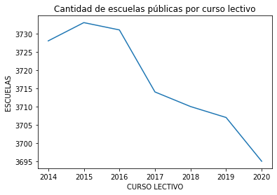

```python
df_public_schools.groupby("CURSO LECTIVO")["CÓDIGO"].count().plot(ylabel="ESCUELAS", title="Cantidad de escuelas públicas por curso lectivo")
```

Un primer dato arrojado por el conteo de escuelas cada año es que no existe un crecimiento o decrecimiento significativo en la apertura de las mismas, e incluso esta cantidad se reduce hasta el año 2020.

Por lo que es importante profundizar sobre los cambios en las aperturas o cierres de escuelas a través de los años. Para esto utilizaremos el código asociado a cada escuela pública.

### Los registros de las escuelas que aparecen o desaparecen a través de 2015 a 2020

Dentro del conteo realizado anteriormente, existe un cambio de comportamiento pequeño en la cantidad total de escuelas abiertas en el país entre 2014 y 2020. Por lo que es importante explorar esos cambios con respecto al paso de los años.

A continuación se realiza un conteo de nuevos registros de escuelas que aparecen en un año, y de registros de escuelas que dejan de aparecer.

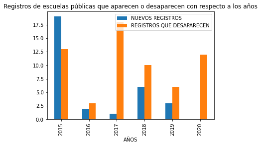

```python
years = list()
new_records = list()
disappear_records = list()

# Ciclo que recorre el margen de tiempo del dataset y compara los valores no repetidos de escuelas entre dos años.
for year in range(2014, 2020):
    year_range = df_public_schools["CURSO LECTIVO"].between(year, year+1)

    unique_schools = df_public_schools[year_range].drop_duplicates(subset=["CÓDIGO"], keep=False)

    n_new_records = len(unique_schools[unique_schools["CURSO LECTIVO"] == year+1])

    n_disappear_records = len(unique_schools[unique_schools["CURSO LECTIVO"] == year])

    years.append(year+1)
    new_records.append(n_new_records)
    disappear_records.append(n_disappear_records)


d = {'AÑOS': years, "NUEVOS REGISTROS": new_records, "REGISTROS QUE DESAPARECEN": disappear_records}

df_school_changes = pd.DataFrame(data=d)

df_school_changes.plot(kind="bar", x="AÑOS", title="Registros de escuelas públicas que aparecen o desaparecen con respecto a los años")
```

**Ante el comportamiento con tendencia a decrecer de la apertura y cierre de escuelas públicas, se debe profundizar entonces en el estudio de elementos específicos dentro de cada escuela. Para comprobar si existen mejoras en las condiciones de las mismas, y además cómo se distribuyen estas en las regiones del país.**

Se procederá a explorar la evolución de otros indicadores en las escuelas, para conocer más sobre posibles cambios de infraestructura de aulas y tecnología.

### Evolución de la infraestructura de aulas e infraestructura tecnológica en las escuelas públicas

Un parámetro importante a comprobar es si, a diferencia del decrecimiento en la cantidad de centros educativos, existe un crecimiento en los indicadores de infraestructura de aulas y tecnología, es decir en las siguientes columnas del dataset:

- Aulas o laboratorios de informática
- Computadoras de escritorio con o sin acceso a Internet
- Computadoras portátiles con o sin acceso a Internet
- Acceso a servicio de Internet por parte de las escuelas públicas

#### Evolución en la cantidad de aulas en las escuelas públicas

El dataset clasifica las aulas con el parámetro de "total" y "buenas", esto quiere decir que no toda aula contabilizada está en condiciones óptimas. Aunque el hecho de que no esté en condiciones óptimas, no significa que no se utilice.

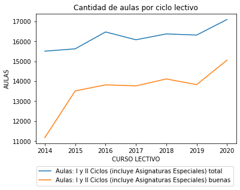

```python
df_public_schools.groupby("CURSO LECTIVO")[["Aulas: I y II Ciclos (incluye Asignaturas Especiales) total", "Aulas: I y II Ciclos (incluye Asignaturas Especiales) buenas"]].sum().plot(ylabel="AULAS", title="Cantidad de aulas por ciclo lectivo").legend(loc='best',bbox_to_anchor=(1, -0.15))
```

**Como se puede observar, existe un crecimiento en la cantidad total de aulas entre el 2014 y el 2020. Con una tasa de crecimiento más significativa en la cantidad de aulas categorizadas como "buenas", de cerca de 4000 de las mismas. Un importante aumento con respecto a las cerca de 11.000 de 2014.**

Lo anterior contrasta frente al ligero decrecimiento en la cantidad de escuelas públicas. Lo que indica que la baja en la cantidad de escuelas no se traduce de forma necesaria en una baja de la calidad de la educación.

#### Evolución en la cantidad de laboratorios públicos en las escuelas públicas

Se procede a realizar el mismo tipo de conteo para los laboratorios informáticos en las escuelas. De la misma forma que las aulas, estos se contabilizan por "total" y "buenos".

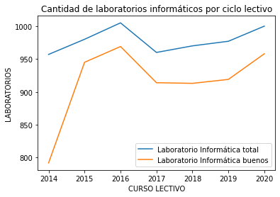

```python
df_public_schools.groupby("CURSO LECTIVO")[["Laboratorio Informática total", "Laboratorio Informática buenos"]].sum().plot(ylabel="LABORATORIOS", title="Cantidad de laboratorios informáticos por ciclo lectivo")
```

Al igual que con el comportamiento de la cantidad de aulas, los laboratorios informáticos crecen, pero de forma más modesta. Incluso, llama la atención su número con respecto a la cantidad de aulas en el país. **A continuación se muestra su proporción a 2020.**

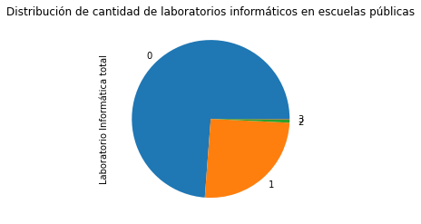

```python
df_to_plot = df_public_schools[df_public_schools["CURSO LECTIVO"] == 2020]

df_to_plot["Laboratorio Informática total"].value_counts().plot(kind="pie", title="Distribución de cantidad de laboratorios informáticos en escuelas públicas")

# plot(kind="pie", y="Laboratorio Informática total")
```

En promedio, un cuarto de las escuelas públicas del país tiene al menos un laboratorio informático. Las que tienen más de un laboratorio representan una cantidad mínima con respecto al total de escuelas públicas.

**Aunque de 2014 a 2020 existe un crecimiento en cerca de 150 nuevos laboratorios informáticos en buen estado, pasando de unos 800 a 950, estos están en una de cada cuatro escuelas en el país. Una cobertura que debe ser mejorada.**

#### Evolución en la cantidad de dispositivos tecnológicos en las escuelas públicas

Es importante conocer el estado de la cantidad de dispositivos tecnológicos adquiridos en los centros educativos, como las computadoras, a través de estos años. Ya que estos son un indicio importante del uso de herramientas tecnológicas para la dinámica educativa.

El dataset clasifica las computadoras en los centros educativos según su uso, **para el interés de este trabajo nos enfocaremos en las de uso didáctico.** Por lo que se estudiarán los siguientes elementos en el dataset:

- Computadoras escritorio con internet, para usos Pedagógicos
- Computadoras escritorio sin internet, para usos Pedagógicos
- Computadoras portátil con internet, para usos Pedagógicos
- Computadoras portátil sin internet, para usos Pedagógicos

Es importante destacar que se contabiliza el acceso a Internet de las mismas, recurso importante para tener un conocimiento de la conectividad.

Primero se analiza el comportamiento a través de los años de la cantidad de computadoras de escritorio en las escuelas públicas.

[figure not shown]

```python
df_public_schools.groupby("CURSO LECTIVO")[["Computadoras escritorio con internet, para usos Pedagógicos", "Computadoras escritorio sin internet, para usos Pedagógicos"]].sum().plot(ylabel="COMPUTADORAS", title="Computadoras de escritorio en las escuelas para uso pedagógico").legend(loc='best',bbox_to_anchor=(1, -0.15))
```

La disponibilidad de computadoras de escritorio ha venido en decrecimiento a través de los años, un factor que llama la atención y el cual debe compararse con el comportamiento de la cantidad de dispositivos portátiles. Los cuales podrían estar creciendo a la inversa -según la tendencia esperable- con respecto al uso de dispositivos de escritorio.

A continuación se procede a graficar la cantidad de dispositivos portátiles disponibles a través de los años en las escuelas públicas.

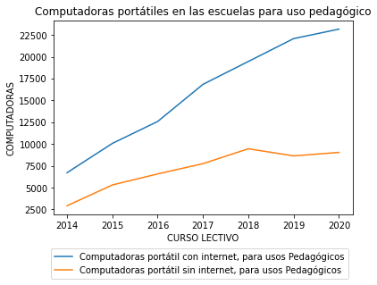

```python
df_public_schools.groupby("CURSO LECTIVO")[["Computadoras portátil con internet, para usos Pedagógicos", "Computadoras portátil sin internet, para usos Pedagógicos"]].sum().plot(ylabel="COMPUTADORAS", title="Computadoras portátiles en las escuelas para uso pedagógico").legend(loc='best',bbox_to_anchor=(1.0, -0.15))
```

### Acceso a Internet en las escuelas públicas

La conectividad a Internet es un elemento fundamental para el uso de nuevas tecnologías, por lo que se estudia el comportamiento del mismo del 2014 al 2020 en las escuelas públicas.

A continuación se grafica el acceso al servicio de Internet por parte de las escuelas a través de los años, según la información que reporta cada centro educativo y que se registra el dataset.

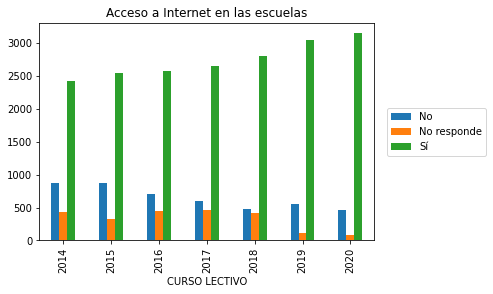

```python
df_to_plot = df_public_schools.groupby("CURSO LECTIVO")["Servicio de Internet"].value_counts().reset_index(name='COUNT')

df_to_plot.pivot_table(index="CURSO LECTIVO", columns="Servicio de Internet", values="COUNT").plot(kind="bar", title="Acceso a Internet en las escuelas").legend(loc='center right', bbox_to_anchor=(1.35, 0.5))
```

Según el paso de los años **el acceso a Internet en las escuelas públicas del país ha aumentado, para 2020 cerca de 3.000 presentan acceso a Internet y menos de 500 escuelas no tienen acceso a este servicio.** El dataset no proporciona información sobre las características técnicas del servicio que posee cada escuela, por lo que no se puede estudiar a mayor profundidad este aspecto.

### Estado regional de la infraestructura educativa e infraestructura tecnológica de las escuelas públicas

Después de analizar de forma general cómo he evolucionado la infraestructura de aulas y de tecnología, es importante poder evaluar a detalle su comportamiento a nivel regional en el país. Para así identificar el avance por provincia en la mejora de condiciones tecnológicas.

A continuación se crea un gráfico lineal con la evolución en la cantidad de aulas por provincia, **el cual será sustituido por mejores formas de visualización.** Sin embargo sirve de ejemplo para explicar el proceso de análisis emprendido para exponer de una mejor forma la información a estudiar.

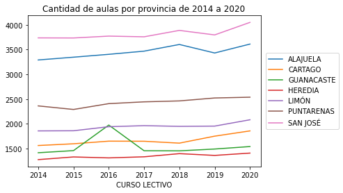

```python
df_to_plot = df_public_schools.groupby(["CURSO LECTIVO", "PROVINCIA"])[["Aulas: I y II Ciclos (incluye Asignaturas Especiales) total", "Aulas: I y II Ciclos (incluye Asignaturas Especiales) buenas"]].sum().reset_index()

df_to_plot.pivot_table(index="CURSO LECTIVO", columns="PROVINCIA", values=["Aulas: I y II Ciclos (incluye Asignaturas Especiales) total"]).plot(title="Cantidad de aulas por provincia de 2014 a 2020")

plt.legend(["ALAJUELA", "CARTAGO", "GUANACASTE", "HEREDIA", "LIMÓN", "PUNTARENAS", "SAN JOSÉ"], loc='center right', bbox_to_anchor=(1.35, 0.5))
```

Como se muestra en el gráfico lineal anterior, entender la evolución de la infraestructura a través del tiempo y de forma segregada por provincias es algo complicado. Por lo que **se reformula la creación de gráficos tomando solo dos puntos: el 2014 y el 2020.** Así se procederá a comparar la evolución total de forma segregada, permitiendo la generación de gráficos más fáciles de entender.

#### Evolución regional en la infraestructura de aulas en las escuelas públicas

La cantidad de aulas "totales" y "buenas" y su evolución, como se quería mostrar en el gráfico anterior, se reformula. Por lo que se generan dos gráficos separados, que permiten ver el salto de 2014 a 2020 por provincia en ambas categorías.

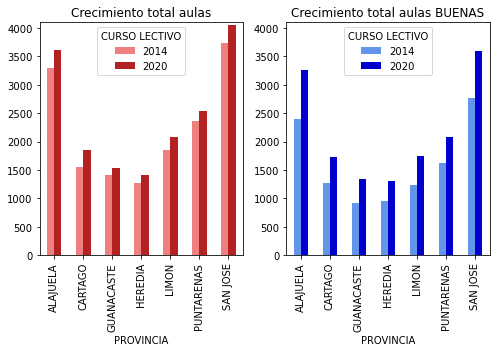

```python
fig, (ax1, ax2) = plt.subplots(nrows=1, ncols=2, figsize=(7,5))

df_to_plot = df_public_schools.groupby(["CURSO LECTIVO", "PROVINCIA"])[["Aulas: I y II Ciclos (incluye Asignaturas Especiales) total", "Aulas: I y II Ciclos (incluye Asignaturas Especiales) buenas"]].sum().reset_index()

df_to_plot_mask_2014 = df_to_plot["CURSO LECTIVO"] == 2014
df_to_plot_mask_2020 = df_to_plot["CURSO LECTIVO"] == 2020

df_to_plot = df_to_plot[df_to_plot_mask_2014 | df_to_plot_mask_2020]

df_to_plot.pivot_table(index="PROVINCIA", columns="CURSO LECTIVO", values="Aulas: I y II Ciclos (incluye Asignaturas Especiales) total").plot(ax=ax1, kind="bar", title="Crecimiento total aulas", ylim=(0,4100), color=["lightcoral", "firebrick"])

df_to_plot.pivot_table(index="PROVINCIA", columns="CURSO LECTIVO", values="Aulas: I y II Ciclos (incluye Asignaturas Especiales) buenas").plot(ax=ax2, kind="bar", title="Crecimiento total aulas BUENAS", ylim=(0,4100), color=["cornflowerblue", "mediumblue"])

fig.tight_layout()
```

```python
df_to_pivot = df_public_schools.groupby(["CURSO LECTIVO", "PROVINCIA"])[["Aulas: I y II Ciclos (incluye Asignaturas Especiales) buenas"]].sum().reset_index()

df_to_plot_mask_2014 = df_to_pivot["CURSO LECTIVO"] == 2014
df_to_plot_mask_2020 = df_to_pivot["CURSO LECTIVO"] == 2020

df_to_pivot = df_to_pivot[df_to_plot_mask_2014 | df_to_plot_mask_2020]

df_pivot = df_to_pivot.pivot_table(index="PROVINCIA", columns="CURSO LECTIVO", values="Aulas: I y II Ciclos (incluye Asignaturas Especiales) buenas")

print("Crecimiento de aulas en buen estado de 2014 a 2020:\n")
print(df_pivot[2020] - df_pivot[2014])

print("\nPromedio de crecimiento de aulas en buen estado: " + str((df_pivot[2020] - df_pivot[2014]).mean()))
```

[output not shown]

Tomando la información mostrada, se puede apreciar cómo hay una mayor tasa de crecimiento en el total de aulas buenas. Además, su crecimiento se comporta de manera similar en todas las provincias, excepto en Alajuela y San José, donde la cantidad de las mismas crece en mayor porcentaje. **En promedio, de 2014 a 2020, aumentó la cantidad de aulas en buen estado por provincia en cerca de 554. Siendo Alajuela en donde más aumentaron (859) y Heredia en donde menos (353).**

#### Evolución regional en la infraestructura de laboratorios informáticos en las escuelas públicas

Del mismo modo se debe explorar el crecimiento en la cantidad de laboratorios informáticos por provincia.

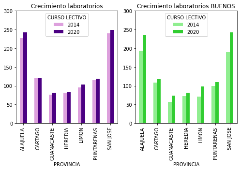

```python
fig, (ax1, ax2) = plt.subplots(nrows=1, ncols=2, figsize=(7,5))

df_to_plot = df_public_schools.groupby(["CURSO LECTIVO", "PROVINCIA"])[["Laboratorio Informática total", "Laboratorio Informática buenos"]].sum().reset_index()

df_to_plot_mask_2014 = df_to_plot["CURSO LECTIVO"] == 2014
df_to_plot_mask_2020 = df_to_plot["CURSO LECTIVO"] == 2020

df_to_plot = df_to_plot[df_to_plot_mask_2014 | df_to_plot_mask_2020]

df_to_plot.pivot_table(index="PROVINCIA", columns="CURSO LECTIVO", values="Laboratorio Informática total").plot(ax=ax1, kind="bar", title="Crecimiento laboratorios", ylim=(0,300), color=["plum", "indigo"])

df_to_plot.pivot_table(index="PROVINCIA", columns="CURSO LECTIVO", values="Laboratorio Informática buenos").plot(ax=ax2, kind="bar", title="Crecimiento laboratorios BUENOS", ylim=(0,300), color=["lightgreen", "limegreen"])

fig.tight_layout()
```

```python
df_to_pivot = df_public_schools.groupby(["CURSO LECTIVO", "PROVINCIA"])[["Laboratorio Informática buenos"]].sum().reset_index()

df_to_plot_mask_2014 = df_to_pivot["CURSO LECTIVO"] == 2014
df_to_plot_mask_2020 = df_to_pivot["CURSO LECTIVO"] == 2020

df_to_pivot = df_to_pivot[df_to_plot_mask_2014 | df_to_plot_mask_2020]

df_pivot = df_to_pivot.pivot_table(index="PROVINCIA", columns="CURSO LECTIVO", values="Laboratorio Informática buenos")

print("Crecimiento de laboratorios informáticos en buen estado de 2014 a 2020:\n")
print(df_pivot[2020] - df_pivot[2014])

print("\nPromedio de crecimiento de laboratorios informáticos en buen estado: " + str((df_pivot[2020] - df_pivot[2014]).mean()))
```

[output not shown]

En menor escala que el crecimiento de aulas pero con un comportamiento similar, **los laboratorios de informática crecieron en promedio en 23 por provincia, siendo San José la provincia con mayor aumento (52) y Heredia (8), Cartago (9) y Puntarenas (10) las provincia con menor aumento.** Siendo las provincias de Cartago, Heredia y Puntarenas donde menos crecimiento de los mismos hubo, mientras que Alajuela y San José fue donde se presentó un mayor crecimiento de los laboratorios informáticos.

#### Evolución regional en la adquisición de equipo tecnológico en las escuelas públicas

Como se observó en el panorama general, el crecimiento de computadoras portátiles desde el año 2014 a la actualidad representó una alta tasa de crecimiento. Por lo que a continuación se profundiza sobre su crecimiento a nivel regional.

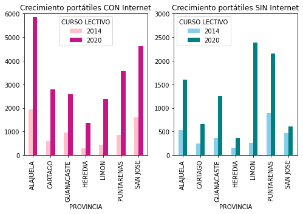

```python
fig, (ax1, ax2) = plt.subplots(nrows=1, ncols=2, figsize=(7,5))

df_to_plot = df_public_schools.groupby(["CURSO LECTIVO", "PROVINCIA"])[["Computadoras portátil con internet, para usos Pedagógicos", "Computadoras portátil sin internet, para usos Pedagógicos"]].sum().reset_index()

df_to_plot_mask_2014 = df_to_plot["CURSO LECTIVO"] == 2014
df_to_plot_mask_2020 = df_to_plot["CURSO LECTIVO"] == 2020

df_to_plot = df_to_plot[df_to_plot_mask_2014 | df_to_plot_mask_2020]

df_to_plot.pivot_table(index="PROVINCIA", columns="CURSO LECTIVO", values="Computadoras portátil con internet, para usos Pedagógicos").plot(ax=ax1, kind="bar", title="Crecimiento portátiles CON Internet", ylim=(0,6000), color=["pink", "mediumvioletred"]).legend(loc='upper center', title="CURSO LECTIVO")

df_to_plot.pivot_table(index="PROVINCIA", columns="CURSO LECTIVO", values="Computadoras portátil sin internet, para usos Pedagógicos").plot(ax=ax2, kind="bar", title="Crecimiento portátiles SIN Internet", ylim=(0,3000), color=["skyblue", "teal"])

fig.tight_layout()
```

```python
df_to_pivot = df_public_schools.groupby(["CURSO LECTIVO", "PROVINCIA"])[["Computadoras portátil con internet, para usos Pedagógicos"]].sum().reset_index()

df_to_plot_mask_2014 = df_to_pivot["CURSO LECTIVO"] == 2014
df_to_plot_mask_2020 = df_to_pivot["CURSO LECTIVO"] == 2020

df_to_pivot = df_to_pivot[df_to_plot_mask_2014 | df_to_plot_mask_2020]

df_pivot = df_to_pivot.pivot_table(index="PROVINCIA", columns="CURSO LECTIVO", values="Computadoras portátil con internet, para usos Pedagógicos")

print("Crecimiento de computadoras portátiles con internet, para usos pedagógicos de 2014 a 2020:\n")
print(df_pivot[2020] - df_pivot[2014])

print("\nPromedio de crecimiento: " + str((df_pivot[2020] - df_pivot[2014]).mean()))
```

```
Crecimiento de computadoras portátiles con internet, para usos pedagógicos de 2014 a 2020:

PROVINCIA
ALAJUELA      3923
CARTAGO       2196
GUANACASTE    1625
HEREDIA       1082
LIMON         1937
PUNTARENAS    2696
SAN JOSE      2998
dtype: int16

Promedio de crecimiento: 2351.0
```

```python
df_to_pivot = df_public_schools.groupby(["CURSO LECTIVO", "PROVINCIA"])[["Computadoras portátil sin internet, para usos Pedagógicos"]].sum().reset_index()

df_to_plot_mask_2014 = df_to_pivot["CURSO LECTIVO"] == 2014
df_to_plot_mask_2020 = df_to_pivot["CURSO LECTIVO"] == 2020

df_to_pivot = df_to_pivot[df_to_plot_mask_2014 | df_to_plot_mask_2020]

df_pivot = df_to_pivot.pivot_table(index="PROVINCIA", columns="CURSO LECTIVO", values="Computadoras portátil sin internet, para usos Pedagógicos")

print("Crecimiento de computadoras portátiles sin internet, para usos pedagógicos de 2014 a 2020:\n")
print(df_pivot[2020] - df_pivot[2014])

print("\nPromedio de crecimiento: " + str((df_pivot[2020] - df_pivot[2014]).mean()))
```

```
Crecimiento de computadoras portátiles sin internet, para usos pedagógicos de 2014 a 2020:

PROVINCIA
ALAJUELA      1073
CARTAGO        414
GUANACASTE     884
HEREDIA        210
LIMON         2133
PUNTARENAS    1267
SAN JOSE       136
dtype: int16

Promedio de crecimiento: 873.8571428571429
```

### Estado regional del acceso a Internet en las escuelas públicas

El acceso a Internet es uno de los puntos fundamentales para el aprovechamiento de los nuevos recursos tecnológicos en la educación. En esta sección se profundiza sobre su evolución de 2014 a 2020 en cada provincia.

A continuación se grafica el cambio por cada provincia, de 2014 a 2020, en el acceso a Internet por escuela. Lo cual permite ver en cuáles provincia hubo un mayor aumento de este servicio.

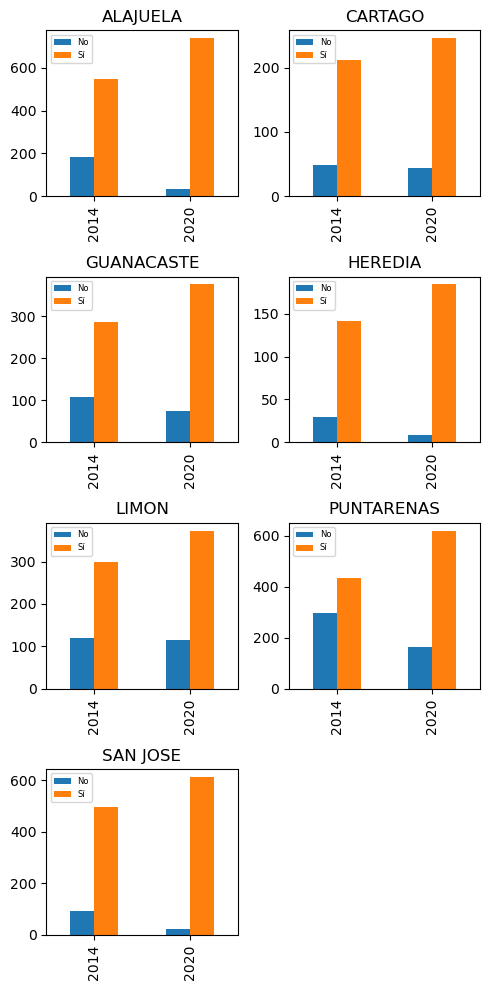

```python
fig, ax = plt.subplots(ncols=2, nrows=4, figsize=(5,10), dpi=100)

df_to_plot = df_public_schools.groupby(["CURSO LECTIVO", "PROVINCIA"])["Servicio de Internet"].value_counts().reset_index(name='COUNT')

df_to_plot_mask_2014 = df_to_plot["CURSO LECTIVO"] == 2014
df_to_plot_mask_2020 = df_to_plot["CURSO LECTIVO"] == 2020
df_to_plot_mask_not_NR = df_to_plot["Servicio de Internet"] != "No responde"

df_to_plot = df_to_plot[(df_to_plot_mask_2014 | df_to_plot_mask_2020) & df_to_plot_mask_not_NR]

i = 0
j = 0

for category in df_to_plot["PROVINCIA"].cat.categories:
    df_to_subplot = df_to_plot[df_to_plot["PROVINCIA"] == category]

    df_to_subplot.pivot_table(index="CURSO LECTIVO", columns="Servicio de Internet", values="COUNT").plot(ax=ax[j][i%2], kind="bar", title=category, xlabel="").legend(prop={'size': 6})

    i += 1
    j += 1 if i%2 == 0 else 0

fig.delaxes(ax[3][1])
fig.tight_layout()
```

El gráfico compuesto de arriba ayuda a describir la evolución en cada provincia en el acceso a Internet. En estas se puede destacar lo positivo del cambio en la tasa de acceso a Internet en los centros educativos de Alajuela, Heredia y San José. Otras provincias que representan un avance medio en el acceso a Internet como Puntarenas y Guanacaste.

Sin embargo, la tasa de acceso a Internet no se vio significativamente cambiada en las provincias de Cartago y Limón.

## Conclusiones

Desde un análisis de la información relativa a infraestructura de aulas y de tecnología, en este proyecto se logró conocer algunos factores de la evolución en las escuelas del país a través de los últimos años. Entre las principales conclusiones se puede destacar:

La evolución del sistema educativo público de primaria en Costa Rica, desde la infraestructura de aulas y de tecnología, se ha dado más en la mejora de la calidad de los servicios que ya brindan las escuelas existentes y no desde la creación de más centros educativos. Con saltos importantes en el aumento de aulas en buen estado en todas las provincias, así como la dotación de una mayor cantidad de computadoras portátiles como herramienta pedagógica.

En el ámbito de deudas en el crecimiento del sistema educativo, el acceso a Internet no tuvo cambios significativos (como en las otras regiones) en las provincias de Cartago y Limón. Este punto es fundamental para el aprovechamiento en el crecimiento de recursos tecnológicos, como las computadoras portátiles adquiridas en la región (mismas que sí presentaron una tasa importante de crecimiento).

Tras el análisis de los diversos datos presentados se puede concluir que de 2014 a 2020, en ámbitos los ámbitos estudiados, ha existido una importante mejora de las condiciones en muchas escuelas del país. Mismas que deben seguirse promoviendo para una mejor prestación de la educación pública en el futuro.